# NYC Taxi Trip Duration Prediction

```python
!pip install xgboost
```

```
     ━━━━━━━━━━━━━━━━━━━━━━━━━━━━━━━━━━━━━━━ 193.6/193.6 MB 4.8 MB/s eta 0:00:0000:0100:01
```

```python
!pip install haversine
```

```python
!pip install pyathena
```

[output not shown]

## Import libraries

```python
import numpy as np
import pandas as pd
import seaborn as sns
import matplotlib.pyplot as plt
import datetime as dt
from sklearn.linear_model import LinearRegression
from sklearn.ensemble import RandomForestRegressor
from xgboost import XGBRegressor
from sklearn import metrics
from sklearn.model_selection import train_test_split, GridSearchCV
from haversine import haversine
import statsmodels.formula.api as sm
from sklearn.model_selection import learning_curve
from sklearn.model_selection import ShuffleSplit
import warnings; warnings.simplefilter('ignore')
```

## Import Dataset

```python
from pyathena import connect
import pandas as pd
conn = connect(s3_staging_dir='s3://nyc-athena-staging/',
               region_name='us-east-1')

data = pd.read_sql("SELECT * FROM nycitytaxianalysis.canonicaldata limit 1000000", conn)
data
```

|  | vendorid | pickup_date | dropoff_date | passenger_count | trip_distance | pickup_longitude | pickup_latitude | ratecodeid | store_and_fwd_flag | dropoff_longitude | dropoff_latitude | payment_type | fare_amount | extra | mta_tax | tip_amount | tolls_amount | improvement_surcharge | total_amount | type |
| --- | --- | --- | --- | --- | --- | --- | --- | --- | --- | --- | --- | --- | --- | --- | --- | --- | --- | --- | --- | --- |
| 0 | 2.0 | 2016-01-10 01:34:36 | 2016-01-10 01:39:18 | 3.0 | 1.01 | -73.994087 | 40.728176 | 1.0 | N | -73.999008 | 40.717354 | 1.0 | 5.5 | 0.5 | 0.5 | 1.36 | 0.0 | 0.3 | 8.16 | yellow |
| 1 | 2.0 | 2016-01-10 01:34:36 | 2016-01-10 01:46:25 | 1.0 | 2.14 | -73.999641 | 40.728527 | 1.0 | N | -73.979500 | 40.749249 | 1.0 | 10.5 | 0.5 | 0.5 | 2.95 | 0.0 | 0.3 | 14.75 | yellow |
| 2 | 2.0 | 2016-01-10 01:34:36 | 2016-01-10 02:02:37 | 1.0 | 4.87 | -73.988983 | 40.726799 | 1.0 | N | -73.943352 | 40.718811 | 1.0 | 22.0 | 0.5 | 0.5 | 4.66 | 0.0 | 0.3 | 27.96 | yellow |
| 3 | 2.0 | 2016-01-10 01:34:37 | 2016-01-10 01:42:14 | 3.0 | 1.80 | -73.980431 | 40.748318 | 1.0 | N | -73.962112 | 40.765381 | 2.0 | 8.0 | 0.5 | 0.5 | 0.00 | 0.0 | 0.3 | 9.30 | yellow |
| 4 | 2.0 | 2016-01-10 01:34:37 | 2016-01-10 01:44:33 | 6.0 | 1.38 | -73.986160 | 40.719349 | 1.0 | N | -74.004387 | 40.730560 | 1.0 | 8.5 | 0.5 | 0.5 | 1.96 | 0.0 | 0.3 | 11.76 | yellow |
| ... | ... | ... | ... | ... | ... | ... | ... | ... | ... | ... | ... | ... | ... | ... | ... | ... | ... | ... | ... | ... |
| 999995 | NaN | 2016-01-19 13:33:07 | NaT | NaN | NaN | NaN | NaN | NaN | None | NaN | NaN | NaN | NaN | NaN | NaN | NaN | NaN | NaN | NaN | fhv |
| 999996 | NaN | 2016-01-19 13:33:07 | NaT | NaN | NaN | NaN | NaN | NaN | None | NaN | NaN | NaN | NaN | NaN | NaN | NaN | NaN | NaN | NaN | fhv |
| 999997 | NaN | 2016-01-19 13:33:11 | NaT | NaN | NaN | NaN | NaN | NaN | None | NaN | NaN | NaN | NaN | NaN | NaN | NaN | NaN | NaN | NaN | fhv |
| 999998 | NaN | 2016-01-19 13:33:15 | NaT | NaN | NaN | NaN | NaN | NaN | None | NaN | NaN | NaN | NaN | NaN | NaN | NaN | NaN | NaN | NaN | fhv |
| 999999 | NaN | 2016-01-19 13:33:16 | NaT | NaN | NaN | NaN | NaN | NaN | None | NaN | NaN | NaN | NaN | NaN | NaN | NaN | NaN | NaN | NaN | fhv |

1000000 rows × 20 columns

## Data Exploration

We will explore the data and modify dataset as per the our requirment for the further analysis of the problem.

```python
data.head()
```

|  | vendorid | pickup_date | dropoff_date | passenger_count | trip_distance | pickup_longitude | pickup_latitude | ratecodeid | store_and_fwd_flag | dropoff_longitude | dropoff_latitude | payment_type | fare_amount | extra | mta_tax | tip_amount | tolls_amount | improvement_surcharge | total_amount | type |
| --- | --- | --- | --- | --- | --- | --- | --- | --- | --- | --- | --- | --- | --- | --- | --- | --- | --- | --- | --- | --- |
| 0 | 2.0 | 2016-01-10 01:34:36 | 2016-01-10 01:39:18 | 3.0 | 1.01 | -73.994087 | 40.728176 | 1.0 | N | -73.999008 | 40.717354 | 1.0 | 5.5 | 0.5 | 0.5 | 1.36 | 0.0 | 0.3 | 8.16 | yellow |
| 1 | 2.0 | 2016-01-10 01:34:36 | 2016-01-10 01:46:25 | 1.0 | 2.14 | -73.999641 | 40.728527 | 1.0 | N | -73.979500 | 40.749249 | 1.0 | 10.5 | 0.5 | 0.5 | 2.95 | 0.0 | 0.3 | 14.75 | yellow |
| 2 | 2.0 | 2016-01-10 01:34:36 | 2016-01-10 02:02:37 | 1.0 | 4.87 | -73.988983 | 40.726799 | 1.0 | N | -73.943352 | 40.718811 | 1.0 | 22.0 | 0.5 | 0.5 | 4.66 | 0.0 | 0.3 | 27.96 | yellow |
| 3 | 2.0 | 2016-01-10 01:34:37 | 2016-01-10 01:42:14 | 3.0 | 1.80 | -73.980431 | 40.748318 | 1.0 | N | -73.962112 | 40.765381 | 2.0 | 8.0 | 0.5 | 0.5 | 0.00 | 0.0 | 0.3 | 9.30 | yellow |
| 4 | 2.0 | 2016-01-10 01:34:37 | 2016-01-10 01:44:33 | 6.0 | 1.38 | -73.986160 | 40.719349 | 1.0 | N | -74.004387 | 40.730560 | 1.0 | 8.5 | 0.5 | 0.5 | 1.96 | 0.0 | 0.3 | 11.76 | yellow |

### Feature details:

- id - a unique identifier for each trip
- vendorid - a code indicating the provider associated with the trip record
- pickup_datetime - date and time when the meter was engaged
- dropoff_datetime - date and time when the meter was disengaged
- passenger_count - the number of passengers in the vehicle (driver entered value)
- pickup_longitude - the longitude where the meter was engaged
- pickup_latitude - the latitude where the meter was engaged
- dropoff_longitude - the longitude where the meter was disengaged
- dropoff_latitude - the latitude where the meter was disengaged
- store_and_fwd_flag - This flag indicates whether the trip record was held in vehicle memory before sending to the vendor because the vehicle did not have a connection to the server - Y=store and forward; N=not a store and forward trip.

### Label details:

- trip_duration - duration of the trip in seconds

```python
#Check shape of dataset
data.shape
```

```
(1000000, 20)
```

```python
data.dropna(inplace=True)
```

```python
#Check shape of dataset
data.shape
```

```
(481280, 20)
```

```python
#Check for NaN values
data.isnull().sum()
```

```
vendorid                 0
pickup_date              0
dropoff_date             0
passenger_count          0
trip_distance            0
pickup_longitude         0
pickup_latitude          0
ratecodeid               0
store_and_fwd_flag       0
dropoff_longitude        0
dropoff_latitude         0
payment_type             0
fare_amount              0
extra                    0
mta_tax                  0
tip_amount               0
tolls_amount             0
improvement_surcharge    0
total_amount             0
type                     0
dtype: int64
```

```python
#Convert timestamp to datetime format to fetch the other details as listed below
data['pickup_date'] = pd.to_datetime(data['pickup_date'])
data['dropoff_date'] = pd.to_datetime(data['dropoff_date'])
```

```python
#Calculate and assign new columns to the dataframe such as weekday,
#month and pickup_hour which will help us to gain more insights from the data.
# data['weekday'] = data.pickup_date.dt.weekday_name
data['month'] = data.pickup_date.dt.month
data['weekday_num'] = data.pickup_date.dt.weekday
data['pickup_hour'] = data.pickup_date.dt.hour
```

```python
#calc_distance is a function to calculate distance between pickup and dropoff coordinates using Haversine formula.
def calc_distance(df):
    pickup = (df['pickup_latitude'], df['pickup_longitude'])
    drop = (df['dropoff_latitude'], df['dropoff_longitude'])

    return haversine(pickup, drop)
```

```python
data['trip_duration'] = (data['dropoff_date'] - data['pickup_date'])
data['trip_duration'] = data['trip_duration'].dt.total_seconds()
data['trip_duration']
```

```
0          282.0
1          709.0
2         1681.0
3          457.0
4          596.0
           ...
995323     230.0
995324     242.0
995325     509.0
995326    1877.0
995327     496.0
Name: trip_duration, Length: 481280, dtype: float64
```

```python
#Calculate distance and assign new column to the dataframe.
data['distance'] = data.apply(lambda x: calc_distance(x), axis = 1)
```

```python
#Calculate Speed in km/h for further insights
data['speed'] = (data.distance/(data.trip_duration/3600))
```

```python
#Check the type of each variable
data.dtypes.reset_index()
```

|  | index | 0 |
| --- | --- | --- |
| 0 | vendorid | float64 |
| 1 | pickup_date | datetime64[ns] |
| 2 | dropoff_date | datetime64[ns] |
| 3 | passenger_count | float64 |
| 4 | trip_distance | float64 |
| 5 | pickup_longitude | float64 |
| 6 | pickup_latitude | float64 |
| 7 | ratecodeid | float64 |
| 8 | store_and_fwd_flag | object |
| 9 | dropoff_longitude | float64 |
| 10 | dropoff_latitude | float64 |
| 11 | payment_type | float64 |
| 12 | fare_amount | float64 |
| 13 | extra | float64 |
| 14 | mta_tax | float64 |
| 15 | tip_amount | float64 |
| 16 | tolls_amount | float64 |
| 17 | improvement_surcharge | float64 |
| 18 | total_amount | float64 |
| 19 | type | object |
| 20 | month | int64 |
| 21 | weekday_num | int64 |
| 22 | pickup_hour | int64 |
| 23 | trip_duration | float64 |
| 24 | distance | float64 |
| 25 | speed | float64 |

```python
#Dummify all the categorical features like "store_and_fwd_flag, vendorid, month, weekday_num, pickup_hour, passenger_count" except the label i.e. "trip_duration"

dummy = pd.get_dummies(data.store_and_fwd_flag, prefix='flag')
dummy.drop(dummy.columns[0], axis=1, inplace=True) #avoid dummy trap
data = pd.concat([data,dummy], axis = 1)

dummy = pd.get_dummies(data.vendorid, prefix='vendorid')
dummy.drop(dummy.columns[0], axis=1, inplace=True) #avoid dummy trap
data = pd.concat([data,dummy], axis = 1)

dummy = pd.get_dummies(data.month, prefix='month')
dummy.drop(dummy.columns[0], axis=1, inplace=True) #avoid dummy trap
data = pd.concat([data,dummy], axis = 1)

dummy = pd.get_dummies(data.weekday_num, prefix='weekday_num')
dummy.drop(dummy.columns[0], axis=1, inplace=True) #avoid dummy trap
data = pd.concat([data,dummy], axis = 1)

dummy = pd.get_dummies(data.pickup_hour, prefix='pickup_hour')
dummy.drop(dummy.columns[0], axis=1, inplace=True) #avoid dummy trap
data = pd.concat([data,dummy], axis = 1)

dummy = pd.get_dummies(data.passenger_count, prefix='passenger_count')
dummy.drop(dummy.columns[0], axis=1, inplace=True) #avoid dummy trap
data = pd.concat([data,dummy], axis = 1)
```

```python
data.head()
```

|  | vendorid | pickup_date | dropoff_date | passenger_count | trip_distance | pickup_longitude | pickup_latitude | ratecodeid | store_and_fwd_flag | dropoff_longitude | ... | pickup_hour_23 | passenger_count_1.0 | passenger_count_2.0 | passenger_count_3.0 | passenger_count_4.0 | passenger_count_5.0 | passenger_count_6.0 | passenger_count_7.0 | passenger_count_8.0 | passenger_count_9.0 |
| --- | --- | --- | --- | --- | --- | --- | --- | --- | --- | --- | --- | --- | --- | --- | --- | --- | --- | --- | --- | --- | --- |
| 0 | 2.0 | 2016-01-10 01:34:36 | 2016-01-10 01:39:18 | 3.0 | 1.01 | -73.994087 | 40.728176 | 1.0 | N | -73.999008 | ... | 0 | 0 | 0 | 1 | 0 | 0 | 0 | 0 | 0 | 0 |
| 1 | 2.0 | 2016-01-10 01:34:36 | 2016-01-10 01:46:25 | 1.0 | 2.14 | -73.999641 | 40.728527 | 1.0 | N | -73.979500 | ... | 0 | 1 | 0 | 0 | 0 | 0 | 0 | 0 | 0 | 0 |
| 2 | 2.0 | 2016-01-10 01:34:36 | 2016-01-10 02:02:37 | 1.0 | 4.87 | -73.988983 | 40.726799 | 1.0 | N | -73.943352 | ... | 0 | 1 | 0 | 0 | 0 | 0 | 0 | 0 | 0 | 0 |
| 3 | 2.0 | 2016-01-10 01:34:37 | 2016-01-10 01:42:14 | 3.0 | 1.80 | -73.980431 | 40.748318 | 1.0 | N | -73.962112 | ... | 0 | 0 | 0 | 1 | 0 | 0 | 0 | 0 | 0 | 0 |
| 4 | 2.0 | 2016-01-10 01:34:37 | 2016-01-10 01:44:33 | 6.0 | 1.38 | -73.986160 | 40.719349 | 1.0 | N | -74.004387 | ... | 0 | 0 | 0 | 0 | 0 | 0 | 1 | 0 | 0 | 0 |

5 rows × 66 columns

Now our dataset is complete for the further analysis before we train our model with optimal variables.

# Univariate Analysis

Univariate analysis is the analysis of one variable. It's major purpose is to describe patterns in the data consisting of single variable.

[figure not shown]

## Passengers

New York City Taxi Passenger Limit says:

- A maximum of 4 passengers can ride in traditional cabs, there are also 5 passenger cabs that look more like minivans.
- A child under 7 is allowed to sit on a passenger's lap in the rear seat in addition to the passenger limit.

So, in total we can assume that maximum 6 passenger can board the new york taxi i.e. 5 adult + 1 minor

```python
pd.options.display.float_format = '{:.2f}'.format #To suppres scientific notation.
data.passenger_count.value_counts()
```

```
1.00    335487
2.00     67595
5.00     31112
3.00     19283
6.00     18785
4.00      8992
0.00        21
8.00         2
9.00         2
7.00         1
Name: passenger_count, dtype: int64
```

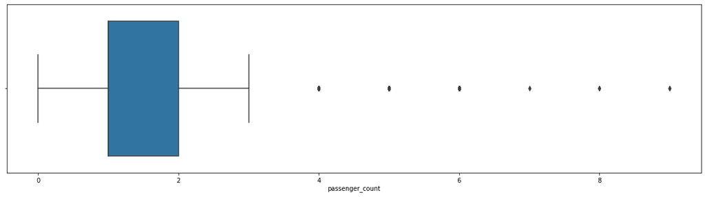

```python
plt.figure(figsize = (20,5))
sns.boxplot(data.passenger_count)
plt.show()
```

### Observations:

- There are some trips with 0 passenger count.
- Few trips consisted of even 7, 8 or 9 passengers. Clear outliers and pointers to data inconsistency
- Most of trip consist of passenger either 1 or 2.

### Idea:

Passenger count is a driver entered value. Since the trip is not possible without passengers. It is evident that the driver forgot to enter the value for the trips with 0 passenger count. Lets analyze the passenger count distribution further to make it consistent for further analysis

```python
data.passenger_count.describe()
```

```
count   481280.00
mean         1.73
std          1.40
min          0.00
25%          1.00
50%          1.00
75%          2.00
max          9.00
Name: passenger_count, dtype: float64
```

As per above details. Mean median and mode are all approx equal to 1. So we would replace the 0 passenger count with 1.

```python
data['passenger_count'] = data.passenger_count.map(lambda x: 1 if x == 0 else x)
```

Also, we will remove the records with passenger count > 7, 8 or 9 as they are extreme values and looks very odd to be ocupied in a taxi.

```python
data = data[data.passenger_count <= 6]
```

```python
data.passenger_count.value_counts()
```

```
1.00    335508
2.00     67595
5.00     31112
3.00     19283
6.00     18785
4.00      8992
Name: passenger_count, dtype: int64
```

Now the data is consistent with respect to the passenger count. Let's take a look at the ditribution with a graph below

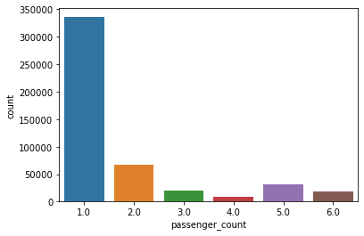

```python
sns.countplot(data.passenger_count)
plt.show()
```

It is evident that most of the trips was taken by single passenger and that is inline with our day to day observations

## Vendor

Here we analyze taxi data only for the 2 vendors which are listed as 1 and 2 in the datset.

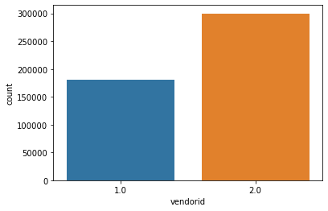

```python
sns.countplot(data.vendorid)
plt.show()
```

## Distance

Let's now have a look on the distribution of the distance across the different types of rides.

[figure not shown]

```python
print(data.distance.describe())
```

```
count   481275.00
mean        33.63
std        511.19
min          0.00
25%          1.18
50%          2.02
75%          3.77
max       8721.03
Name: distance, dtype: float64
```

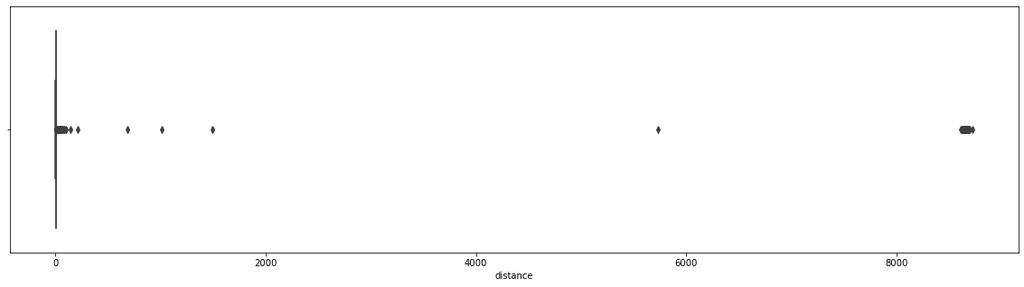

```python
plt.figure(figsize = (20,5))
sns.boxplot(data.distance)
plt.show()
```

### Interesting find:

- There some trips with over 100 km distance.
- Some of the trips distance value is 0 km.

### Observations:

```python
print("There are {} trip records with 0 km distance".format(data.distance[data.distance == 0 ].count()))
```

```
There are 8208 trip records with 0 km distance
```

```python
data[data.distance == 0 ].head()
```

|  | vendorid | pickup_date | dropoff_date | passenger_count | trip_distance | pickup_longitude | pickup_latitude | ratecodeid | store_and_fwd_flag | dropoff_longitude | ... | pickup_hour_23 | passenger_count_1.0 | passenger_count_2.0 | passenger_count_3.0 | passenger_count_4.0 | passenger_count_5.0 | passenger_count_6.0 | passenger_count_7.0 | passenger_count_8.0 | passenger_count_9.0 |
| --- | --- | --- | --- | --- | --- | --- | --- | --- | --- | --- | --- | --- | --- | --- | --- | --- | --- | --- | --- | --- | --- |
| 39 | 2.00 | 2016-01-10 01:34:47 | 2016-01-10 01:34:53 | 1.00 | 0.00 | 0.00 | 0.00 | 5.00 | N | 0.00 | ... | 0 | 1 | 0 | 0 | 0 | 0 | 0 | 0 | 0 | 0 |
| 46 | 2.00 | 2016-01-10 01:34:50 | 2016-01-10 01:42:52 | 1.00 | 1.40 | 0.00 | 0.00 | 1.00 | N | 0.00 | ... | 0 | 1 | 0 | 0 | 0 | 0 | 0 | 0 | 0 | 0 |
| 50 | 2.00 | 2016-01-10 01:34:51 | 2016-01-10 01:45:09 | 1.00 | 2.86 | -73.97 | 40.71 | 1.00 | N | -73.97 | ... | 0 | 1 | 0 | 0 | 0 | 0 | 0 | 0 | 0 | 0 |
| 171 | 2.00 | 2016-01-10 01:35:26 | 2016-01-10 01:38:09 | 2.00 | 0.15 | 0.00 | 0.00 | 1.00 | N | 0.00 | ... | 0 | 0 | 1 | 0 | 0 | 0 | 0 | 0 | 0 | 0 |
| 195 | 2.00 | 2016-01-10 01:35:34 | 2016-01-10 01:44:57 | 2.00 | 2.94 | -73.97 | 40.78 | 1.00 | N | -73.97 | ... | 0 | 0 | 1 | 0 | 0 | 0 | 0 | 0 | 0 | 0 |

5 rows × 66 columns

### Observations

There is some serious inconsistencies in the data where drop off location is same as the pickup location. We can't think off imputing the distance values considering a correlation with the duration because the dropoff_location coordinates would not be inline with the distance otherwise. We will look more to it in bivariate analysis with the Trip duration.

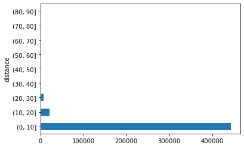

```python
data.distance.groupby(pd.cut(data.distance, np.arange(0,100,10))).count().plot(kind='barh')
plt.show()
```

From the above observation it is evident that most of the rides are completed between 1-10 Kms with some of the rides with distances between 10-30 kms. Other slabs bar are not visible because the number of trips are very less as compared to these slabs

## Trip duration

```python
data.trip_duration.describe()
```

```
count   481275.00
mean       930.30
std       3495.62
min        -47.00
25%        379.00
50%        625.00
75%       1009.00
max      86377.00
Name: trip_duration, dtype: float64
```

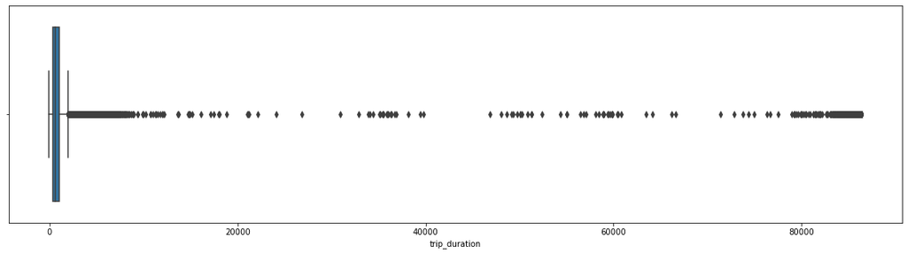

```python
plt.figure(figsize = (20,5))
sns.boxplot(data.trip_duration)
plt.show()
```

### Observations:

Let's analyze more

```python
data.trip_duration.groupby(pd.cut(data.trip_duration, np.arange(1,max(data.trip_duration),3600))).count()
```

```
trip_duration
(1.0, 3601.0]         477143
(3601.0, 7201.0]        2732
(7201.0, 10801.0]         44
(10801.0, 14401.0]        10
(14401.0, 18001.0]         9
(18001.0, 21601.0]         5
(21601.0, 25201.0]         2
(25201.0, 28801.0]         1
(28801.0, 32401.0]         1
(32401.0, 36001.0]        11
(36001.0, 39601.0]         7
(39601.0, 43201.0]         1
(43201.0, 46801.0]         0
(46801.0, 50401.0]         9
(50401.0, 54001.0]         4
(54001.0, 57601.0]         6
(57601.0, 61201.0]        15
(61201.0, 64801.0]         2
(64801.0, 68401.0]         2
(68401.0, 72001.0]         1
(72001.0, 75601.0]         4
(75601.0, 79201.0]         4
(79201.0, 82801.0]        28
Name: trip_duration, dtype: int64
```

### Observations:

Let's look at those trips with huge duration, these are outliers and should be removed for the data consistency.

```python
data[data.trip_duration > 86400]
```

|  | vendorid | pickup_date | dropoff_date | passenger_count | trip_distance | pickup_longitude | pickup_latitude | ratecodeid | store_and_fwd_flag | dropoff_longitude | ... | pickup_hour_23 | passenger_count_1.0 | passenger_count_2.0 | passenger_count_3.0 | passenger_count_4.0 | passenger_count_5.0 | passenger_count_6.0 | passenger_count_7.0 | passenger_count_8.0 | passenger_count_9.0 |
| --- | --- | --- | --- | --- | --- | --- | --- | --- | --- | --- | --- | --- | --- | --- | --- | --- | --- | --- | --- | --- | --- |

0 rows × 66 columns

### Observations:

We should get rid of them for the sake of data consistency. Those are **black** swans !!

```python
data = data[data.trip_duration <= 86400]
```

Let's visualize the number of trips taken in slabs of 0-10, 20-30 ... minutes respectively

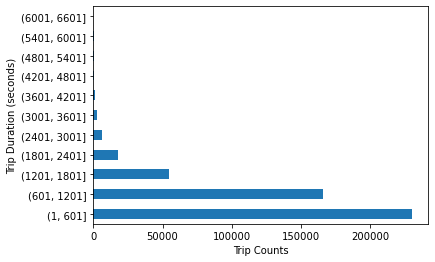

```python
data.trip_duration.groupby(pd.cut(data.trip_duration, np.arange(1,7200,600))).count().plot(kind='barh')
plt.xlabel('Trip Counts')
plt.ylabel('Trip Duration (seconds)')
plt.show()
```

We can observe that most of the trips took 0 - 30 mins to complete i.e. approx 1800 secs. Let's move ahead to next feature.